# Network evaluation report

Claire Rioualen

2020-05-31

# 1 Control sets

## 1.1 Summary of the positive set

| number_of_regulatory_interactions | number_of_TFs |
| --- | --- |
| 2,282 | 155 |

## 1.2 Summary of the negative set

| number_of_regulatory_interactions | number_of_TFs |
| --- | --- |
| 16,410 | 155 |

# 2 Prediction set

## 2.1 Summary of the input prediction set

| number_of_regulatory_interactions | number_of_TFs |
| --- | --- |
| 1,000 | 155 |

# 3 Evaluation of predicted set

## 3.1 TFs evaluated

**List of TFs:** acrR, ada, adiY, agaR, aidB, alaS, allR, araC, arcA, argP, argR, arsR, ascG, atoC, baeR, basR, betI, bglJ, birA, bolA, cadC, caiF, cbl, chbR, cpxR, creB, crp, csgD, cspA, cueR, cusR, cynR, cysB, cytR, dcuR, deoR, dinJ, dnaA, envR, evgA, exuR, fabR, fadR, feaR, fhlA, fis, flhC, flhD, fliZ, fnr, fur, gadE, gadW, gadX, galR, galS, gcvA, glcC, glnG, glpR, gntR, hcaR, hdfR, hipA, hipB, hns, hupA, hupB, iclR, ihfA, ihfB, ilvY, iscR, kdgR, kdpE, lacI, leuO, lexA, lldR, lrhA, lrp, lsrR, malI, malT, marA, marR, mazE, mazF, melR, metJ, metR, mhpR, mlrA, mngR, mntR, modE, nac, nadR, nagC, nanR, narL, narP, nhaR, nikR, norR, nrdR, nsrR, ompR, oxyR, paaX, pdhR, pepA, phoB, phoP, pspF, purR, putA, puuR, qseB, rbsR, rcnR, rcsA, rcsB, relB, relE, rhaR, rhaS, rob, rstA, rutR, sdiA, sgrR, slyA, soxR, soxS, stpA, tdcA, tdcR, torR, treR, trpR, tyrR, uhpA, ulaR, uvrY, uxuR, xylR, yafQ, ydeO, yhaJ, yjjQ, yqhC, zntR, zraR, zur  
**TFs discarded:**

## 3.2 Statistics of the input prediction set

| sensitivity | specificity | precision |
| --- | --- | --- |
| 0.11 | 0.985 | 0.5 |

## 3.3 Confusion matrix

|  | control_positive | control_negative | total_population |
| --- | --- | --- | --- |
| predicted_positive | 250 | 250 | 500 |
| predicted_negative | 2,032 | 16,160 | 18,192 |
| total_control | 2,282 | 16,410 | 18,692 |

Number of interactions not evaluated: 500

Proportion of interactions not evaluated: 0.5

## 3.4 Venn diagrams

### 3.4.1 Comparison of sets

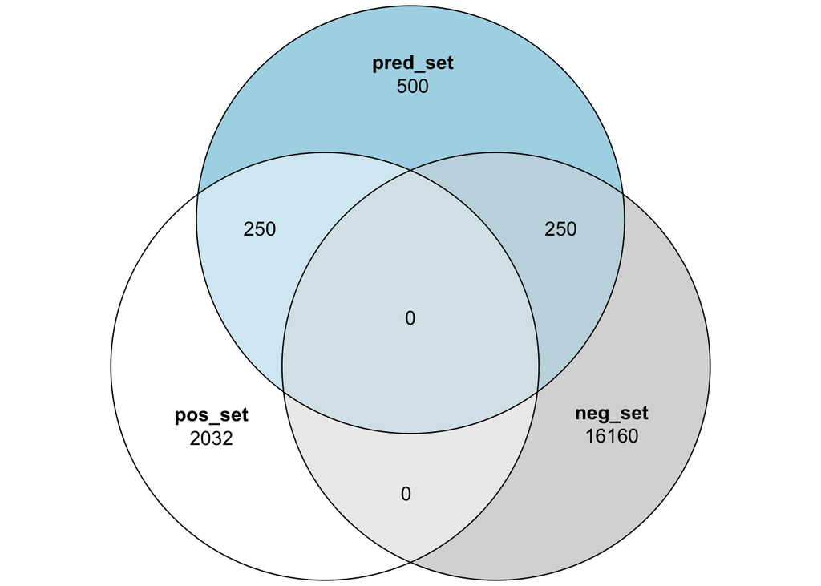

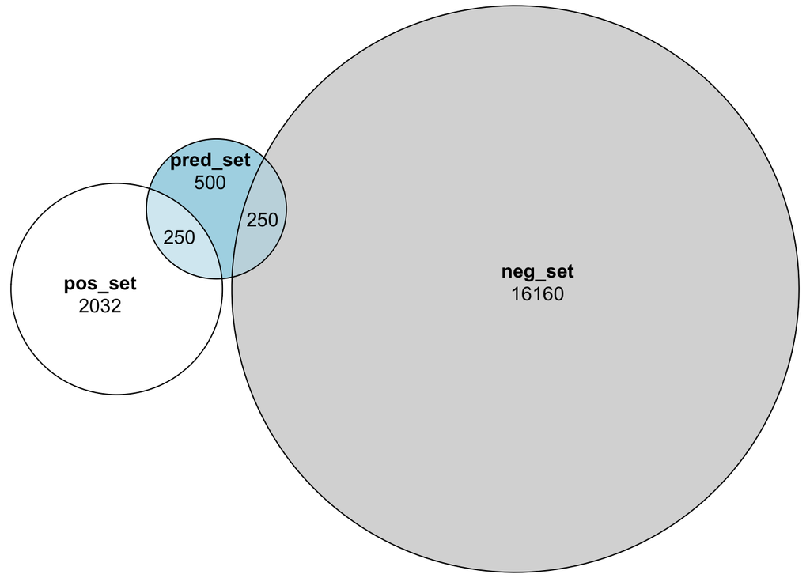

### 3.4.2 Comparison of sets – including all possible interactions

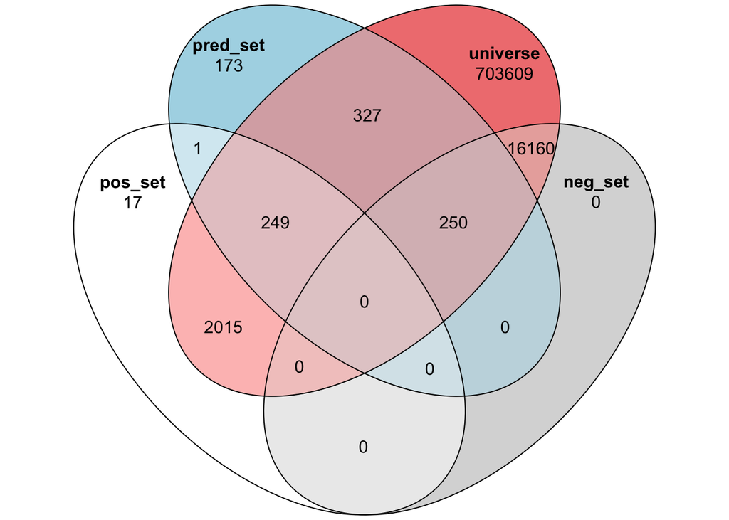

[figure not shown]